# Análisis de microarrays con R

Alex Sánchez

# 1 Introducción

Este documento presenta un análisis *básico* de datos de microarrays para dar respuesta a un problema biológico.

Cada paso del análisis se podría llevar a cabo de distintas formas, lo que podría dar lugar a resultados algo diferentes, pero para facilitar la visión de conjunto, esta diversidad no se presenta ni se discute en este documento, optando por un workflow estandar basado en métodos y herramientas bien consolidados.

## 1.1 El problema biológico

En este caso analizaremos los datos producidos por en un estudio del efecto de la inducción de neuronas dopaminérgicas en fibroblastos de ratones que han sido repositados en [GEO](https://www.ncbi.nlm.nih.gov/geo/) con el identificador GDS4155.

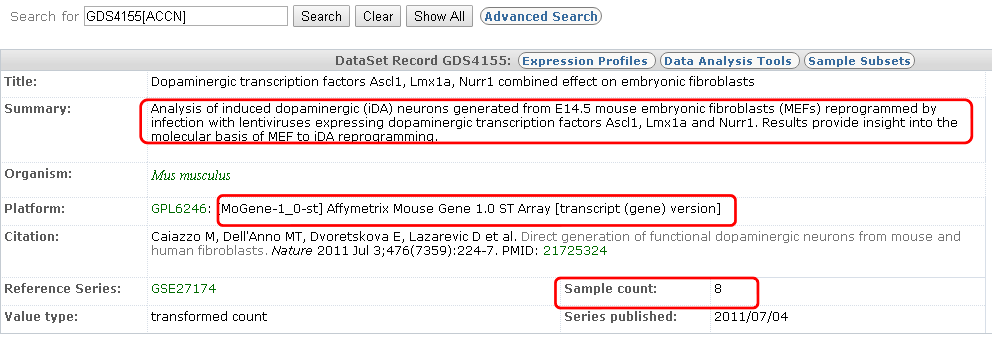

## Preparación del sistema: directorios y paquetes

Aunque no es estrictamente necesario es “buena práctica” organizar los proyectos de una forma determinada para facilitar su gestioón y la reproducibilidad de los mismos.

Esto puede hacerse: - Creando directorios específicos para datos y resultados - Verificando la disponibilidad de las librerías necesarias al principio de la ejecución - Organizando todo el trabajo dentro de un proyecto de Rstudio que esté bajo *control de versiones* en github.

```r
workingDir <- getwd()
dataDir <- file.path(workingDir, "dades")
resultsDir <- file.path(workingDir, "results")
```

```r
if (!require(BiocManager)) install.packages("BiocManager")

installifnot <- function(pkg) {
    if (!require(pkg, character.only = T)) {
        BiocManager::install(pkg)
    }
}
# BiocManager::install() # Actualiza paquetes instalados
installifnot("pd.mogene.1.0.st.v1")
installifnot("mogene10sttranscriptcluster.db")
installifnot("oligo")
installifnot("limma")
installifnot("Biobase")
installifnot("arrayQualityMetrics")
```

```
  There is a binary version available but the source version is later:
        binary source needs_compilation
affyPLM 1.71.0 1.72.0              TRUE
```

```r
installifnot("genefilter")
installifnot("annotate")
installifnot("xtable")
installifnot("gplots")
installifnot("GOstats")
```

# 2 Lectura de los datos

Las muestras se agrupan en dos dos grupos:

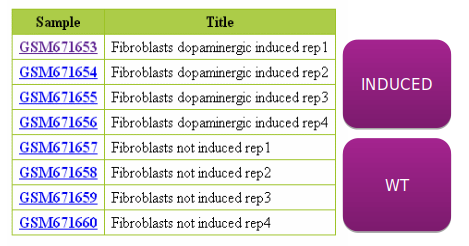

Esta información se almacena en el archivo “targets.csv”

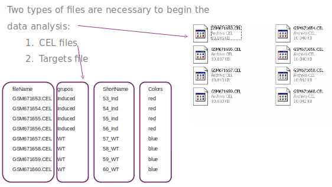

```r
library(Biobase)
# TARGETS
targetsDF <- read.csv(file = file.path(dataDir, "targets.csv"), header = TRUE, sep = ";")
# DEFINE SOME VARIABLES FOR PLOTS
sampleNames <- as.character(targetsDF$ShortName)
sampleColor <- as.character(targetsDF$Colors)
# Creamos un objeto AnnotatedDataFrame
targets <- AnnotatedDataFrame(targetsDF)
```

Al leer los archivos .CEL aportamos la información que contiene el objeto “targets”.

```r
CELfiles <- targetsDF$fileName
rawData <- read.celfiles(file.path(dataDir, CELfiles), phenoData = targets)
```

```
Reading in : C:/Users/asanc/Dropbox (Nuevo Equipo VHIR10)/SotaCV/Analisis_de_datos_omicos-Ejemplo_1-Microarrays/dades/GSM671653.CEL
Reading in : C:/Users/asanc/Dropbox (Nuevo Equipo VHIR10)/SotaCV/Analisis_de_datos_omicos-Ejemplo_1-Microarrays/dades/GSM671654.CEL
Reading in : C:/Users/asanc/Dropbox (Nuevo Equipo VHIR10)/SotaCV/Analisis_de_datos_omicos-Ejemplo_1-Microarrays/dades/GSM671655.CEL
Reading in : C:/Users/asanc/Dropbox (Nuevo Equipo VHIR10)/SotaCV/Analisis_de_datos_omicos-Ejemplo_1-Microarrays/dades/GSM671656.CEL
Reading in : C:/Users/asanc/Dropbox (Nuevo Equipo VHIR10)/SotaCV/Analisis_de_datos_omicos-Ejemplo_1-Microarrays/dades/GSM671657.CEL
Reading in : C:/Users/asanc/Dropbox (Nuevo Equipo VHIR10)/SotaCV/Analisis_de_datos_omicos-Ejemplo_1-Microarrays/dades/GSM671658.CEL
Reading in : C:/Users/asanc/Dropbox (Nuevo Equipo VHIR10)/SotaCV/Analisis_de_datos_omicos-Ejemplo_1-Microarrays/dades/GSM671659.CEL
Reading in : C:/Users/asanc/Dropbox (Nuevo Equipo VHIR10)/SotaCV/Analisis_de_datos_omicos-Ejemplo_1-Microarrays/dades/GSM671660.CEL
```

```r
rawData
```

```
GeneFeatureSet (storageMode: lockedEnvironment)
assayData: 1102500 features, 8 samples
  element names: exprs
protocolData
  rowNames: 1 2 ... 8 (8 total)
  varLabels: exprs dates
  varMetadata: labelDescription channel
phenoData
  rowNames: 1 2 ... 8 (8 total)
  varLabels: fileName grupos ShortName Colors
  varMetadata: labelDescription channel
featureData: none
experimentData: use 'experimentData(object)'
Annotation: pd.mogene.1.0.st.v1
```

# 3 Exploración y control de calidad

## 3.1 Con funciones “ad-hoc”

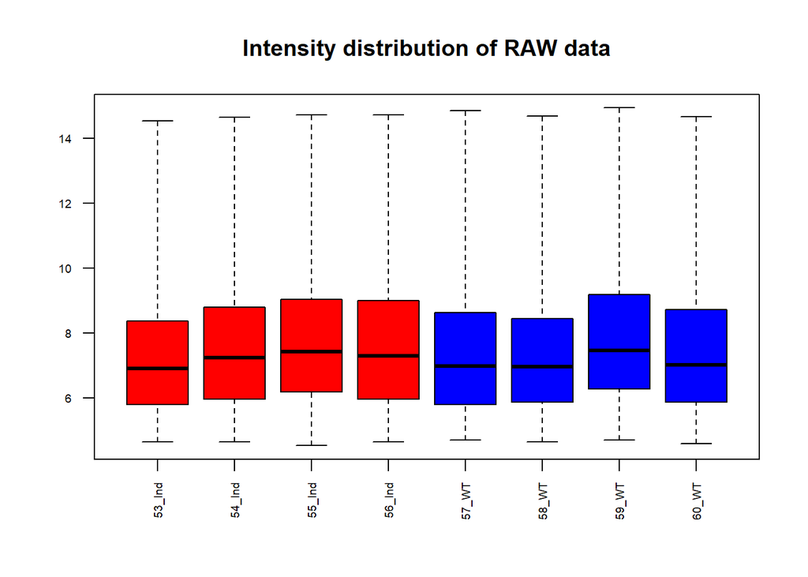

```r
# BOXPLOT
boxplot(rawData, which = "all", las = 2, main = "Intensity distribution of RAW data",
    cex.axis = 0.6, col = sampleColor, names = sampleNames)
```

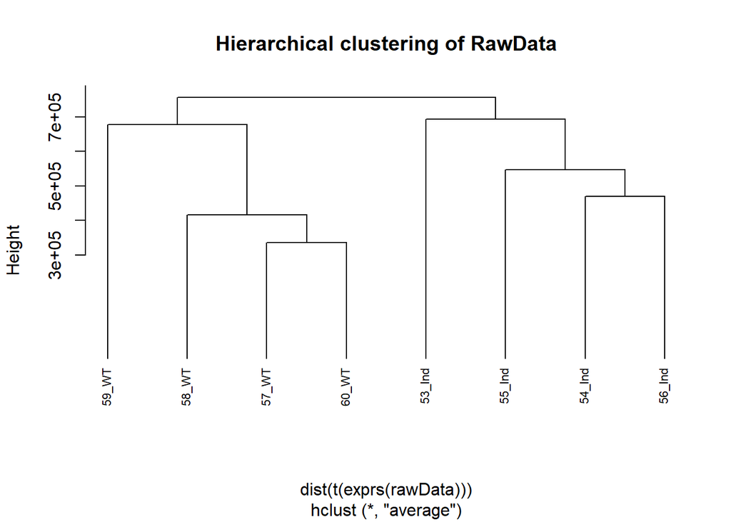

```r
# HIERARQUICAL CLUSTERING
clust.euclid.average <- hclust(dist(t(exprs(rawData))), method = "average")
plot(clust.euclid.average, labels = sampleNames, main = "Hierarchical clustering of RawData",
    cex = 0.7, hang = -1)
```

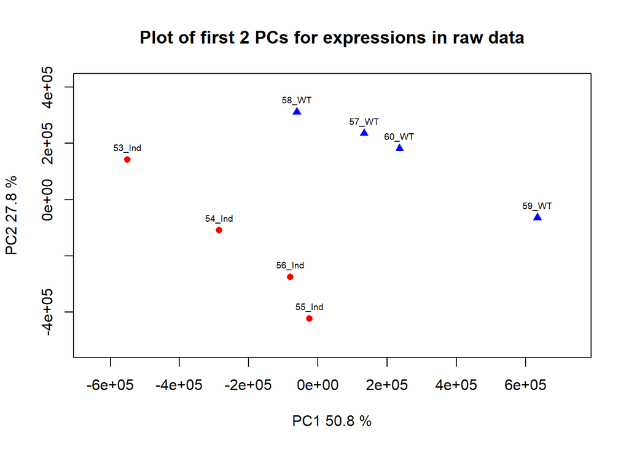

```r
# PRINCIPAL COMPONENT ANALYSIS
plotPCA <- function(X, labels = NULL, colors = NULL, dataDesc = "", scale = FALSE,
    formapunts = NULL, myCex = 0.8, ...) {
    pcX <- prcomp(t(X), scale = scale)  # o prcomp(t(X))
    loads <- round(pcX$sdev^2/sum(pcX$sdev^2) * 100, 1)
    xlab <- c(paste("PC1", loads[1], "%"))
    ylab <- c(paste("PC2", loads[2], "%"))
    if (is.null(colors))
        colors = 1
    plot(pcX$x[, 1:2], xlab = xlab, ylab = ylab, col = colors, pch = formapunts,
        xlim = c(min(pcX$x[, 1]) - 1e+05, max(pcX$x[, 1]) + 1e+05), ylim = c(min(pcX$x[,
            2]) - 1e+05, max(pcX$x[, 2]) + 1e+05))
    text(pcX$x[, 1], pcX$x[, 2], labels, pos = 3, cex = myCex)
    title(paste("Plot of first 2 PCs for expressions in", dataDesc, sep = " "), cex = 0.8)
}

plotPCA(exprs(rawData), labels = sampleNames, dataDesc = "raw data", colors = sampleColor,
    formapunts = c(rep(16, 4), rep(17, 4)), myCex = 0.6)
```

```r
# SAVE TO A FILE
pdf(file.path(resultsDir, "QCPlots_Raw.pdf"))
boxplot(rawData, which = "all", las = 2, main = "Intensity distribution of RAW data",
    cex.axis = 0.6, col = sampleColor, names = sampleNames)
plot(clust.euclid.average, labels = sampleNames, main = "Hierarchical clustering of samples of RawData",
    cex = 0.7, hang = -1)
plotPCA(exprs(rawData), labels = sampleNames, dataDesc = "raw data", colors = sampleColor,
    formapunts = c(rep(16, 4), rep(17, 4)), myCex = 0.6)
dev.off()
```

## 3.2 Control de calidad con el paquete `arrayQualityMetrics`

El control de calidad con arrayQualityMetrics consume cierto tiempo por lo que podemos optar por ejecutarlo, o no hacerlo, usando una variable de tipo lógico.

```r
# Avoid re-running it each time the script is executed.
rerun <- FALSE
if (rerun) {
    arrayQualityMetrics(rawData, reporttitle = "QC_RawData", force = TRUE)
}
```

# 4 Normalización

Utilzamos el método RMA

```r
eset <- rma(rawData)
```

```
Background correcting
Normalizing
Calculating Expression
```

```r
write.exprs(eset, file.path(resultsDir, "NormData.txt"))
eset
```

```
ExpressionSet (storageMode: lockedEnvironment)
assayData: 35556 features, 8 samples
  element names: exprs
protocolData
  rowNames: 1 2 ... 8 (8 total)
  varLabels: exprs dates
  varMetadata: labelDescription channel
phenoData
  rowNames: 1 2 ... 8 (8 total)
  varLabels: fileName grupos ShortName Colors
  varMetadata: labelDescription channel
featureData: none
experimentData: use 'experimentData(object)'
Annotation: pd.mogene.1.0.st.v1
```

# 5 Filtrado

```r
library(genefilter)
annotation(eset) <- "mogene10sttranscriptcluster.db"
eset_filtered <- nsFilter(eset, var.func = IQR, var.cutoff = 0.75, var.filter = TRUE,
    require.entrez = TRUE, filterByQuantile = TRUE)
# NUMBER OF GENES REMOVED
print(eset_filtered)
```

```
$eset
ExpressionSet (storageMode: lockedEnvironment)
assayData: 5042 features, 8 samples
  element names: exprs
protocolData
  rowNames: 1 2 ... 8 (8 total)
  varLabels: exprs dates
  varMetadata: labelDescription channel
phenoData
  rowNames: 1 2 ... 8 (8 total)
  varLabels: fileName grupos ShortName Colors
  varMetadata: labelDescription channel
featureData: none
experimentData: use 'experimentData(object)'
Annotation: mogene10sttranscriptcluster.db

$filter.log
$filter.log$numDupsRemoved
[1] 1943

$filter.log$numLowVar
[1] 15124

$filter.log$numRemoved.ENTREZID
[1] 13447
```

```r
# NUMBER OF GENES IN
print(eset_filtered$eset)
```

```
ExpressionSet (storageMode: lockedEnvironment)
assayData: 5042 features, 8 samples
  element names: exprs
protocolData
  rowNames: 1 2 ... 8 (8 total)
  varLabels: exprs dates
  varMetadata: labelDescription channel
phenoData
  rowNames: 1 2 ... 8 (8 total)
  varLabels: fileName grupos ShortName Colors
  varMetadata: labelDescription channel
featureData: none
experimentData: use 'experimentData(object)'
Annotation: mogene10sttranscriptcluster.db
```

La matriz de datos filtrados se extrae del objeto `filtered$eset$ y se utilizará en los pasos siguientes.

```r
filteredEset <- eset_filtered$eset
filteredData <- exprs(filteredEset)
colnames(filteredData) <- pData(eset_filtered$eset)$ShortName
```

# 6 Selección de genes

Construimos un modelo lineal, es decir una matriz de diseño y una de contrastes, para el análisis.

Primero la matriz de diseño

```r
library(limma)
treat <- pData(filteredEset)$grupos
lev <- factor(treat, levels = unique(treat))
design <- model.matrix(~0 + lev)
colnames(design) <- levels(lev)
rownames(design) <- sampleNames
print(design)
```

```
       Induced WT
53_Ind       1  0
54_Ind       1  0
55_Ind       1  0
56_Ind       1  0
57_WT        0  1
58_WT        0  1
59_WT        0  1
60_WT        0  1
attr(,"assign")
[1] 1 1
attr(,"contrasts")
attr(,"contrasts")$lev
[1] "contr.treatment"
```

A continuación la matriz de contraste

```r
# COMPARISON
cont.matrix1 <- makeContrasts(Induced.vs.WT = Induced - WT, levels = design)
comparisonName <- "Efecto de la Inducción"
print(cont.matrix1)
```

```
         Contrasts
Levels    Induced.vs.WT
  Induced             1
  WT                 -1
```

Estimamos el modelo

```r
# MODEL FIT
fit1 <- lmFit(filteredData, design)
fit.main1 <- contrasts.fit(fit1, cont.matrix1)
fit.main1 <- eBayes(fit.main1)
```

El resultado del análisis se encuentra en el objeto `lmfit` y puede extraerse con la instrucción “topTable”.

Recordemos que la instrucción `topTable` puede aplicar un filtro automàtico, basado en dos criterios distintos, “log fold change” y “p.value”. En este caso retenemos únicamente los genes con un “log-fold-change” mayor de 3 y un p-valor ajustado inferior a 0.05

```r
topTab <- topTable(fit.main1, number = nrow(fit.main1), coef = "Induced.vs.WT", adjust = "fdr",
    lfc = 3, p.value = 0.05)
dim(topTab)
```

```
[1] 219   6
```

```r
head(topTab)
```

```
             logFC  AveExpr         t      P.Value    adj.P.Val        B
10470175  5.707416 7.364107  37.97693 1.509291e-12 5.097665e-09 18.94810
10351443  5.779825 9.600246  36.92244 2.022081e-12 5.097665e-09 18.71070
10403796  5.654198 8.316620  34.73677 3.809647e-12 6.330086e-09 18.18513
10522388  5.531318 8.431707  33.36410 5.787612e-12 6.330086e-09 17.82993
10469358 -5.371210 7.747743 -33.10372 6.277356e-12 6.330086e-09 17.76021
10531869  5.751976 8.785049  31.78336 9.571269e-12 7.060219e-09 17.39446
```

## 6.1 Anotación de los resultados

Obtenemos los identificadores ENTREZ y GENE SYMBOL correspondientes a los probesets (identificados con los id de la compañía que produjo el microarray) que aparecen en la tabla de resultados.

```r
library(mogene10sttranscriptcluster.db)
keytypes(mogene10sttranscriptcluster.db)
```

```
 [1] "ACCNUM"       "ALIAS"        "ENSEMBL"      "ENSEMBLPROT"  "ENSEMBLTRANS"
 [6] "ENTREZID"     "ENZYME"       "EVIDENCE"     "EVIDENCEALL"  "GENENAME"
[11] "GENETYPE"     "GO"           "GOALL"        "IPI"          "MGI"
[16] "ONTOLOGY"     "ONTOLOGYALL"  "PATH"         "PFAM"         "PMID"
[21] "PROBEID"      "PROSITE"      "REFSEQ"       "SYMBOL"       "UNIPROT"
```

```r
anotaciones <- AnnotationDbi::select(mogene10sttranscriptcluster.db, keys = rownames(filteredData),
    columns = c("ENTREZID", "SYMBOL"))
```

Añadimos las columnas de anotaciones a la “topTable”.

Aunque esto se puede hacer de muchas formas utilizamos la metodología de concatenar las instrucciones usando “pipes” (%>%) y funciones del paquete `dplyr` que simplifican la lectura.

```r
library(dplyr)
topTabAnotada <- topTab %>%
    mutate(PROBEID = rownames(topTab)) %>%
    left_join(anotaciones) %>%
    arrange(P.Value) %>%
    select(7, 8, 9, 1:6)

head(topTabAnotada)
```

```
   PROBEID ENTREZID  SYMBOL     logFC  AveExpr         t      P.Value
1 10470175   227627   Obp2a  5.707416 7.364107  37.97693 1.509291e-12
2 10351443   110648   Lmx1a  5.779825 9.600246  36.92244 2.022081e-12
3 10403796   218038    Amph  5.654198 8.316620  34.73677 3.809647e-12
4 10522388   231290 Slc10a4  5.531318 8.431707  33.36410 5.787612e-12
5 10469358    17533    Mrc1 -5.371210 7.747743 -33.10372 6.277356e-12
6 10531869    26414  Mapk10  5.751976 8.785049  31.78336 9.571269e-12
     adj.P.Val        B
1 5.097665e-09 18.94810
2 5.097665e-09 18.71070
3 6.330086e-09 18.18513
4 6.330086e-09 17.82993
5 6.330086e-09 17.76021
6 7.060219e-09 17.39446
```

El resultado se puede escribir a un archivo de texto o a un archivo html

```r
write.csv2(topTabAnotada, file = file.path(resultsDir, "Genes seleccionados.csv"))
print(xtable(topTab, align = "lllllll"), type = "html", html.table.attributes = "",
    file = file.path(resultsDir, "Genes seleccionados.html"))
```

## 6.2 Visualización de resultados (1): Volcano Plot

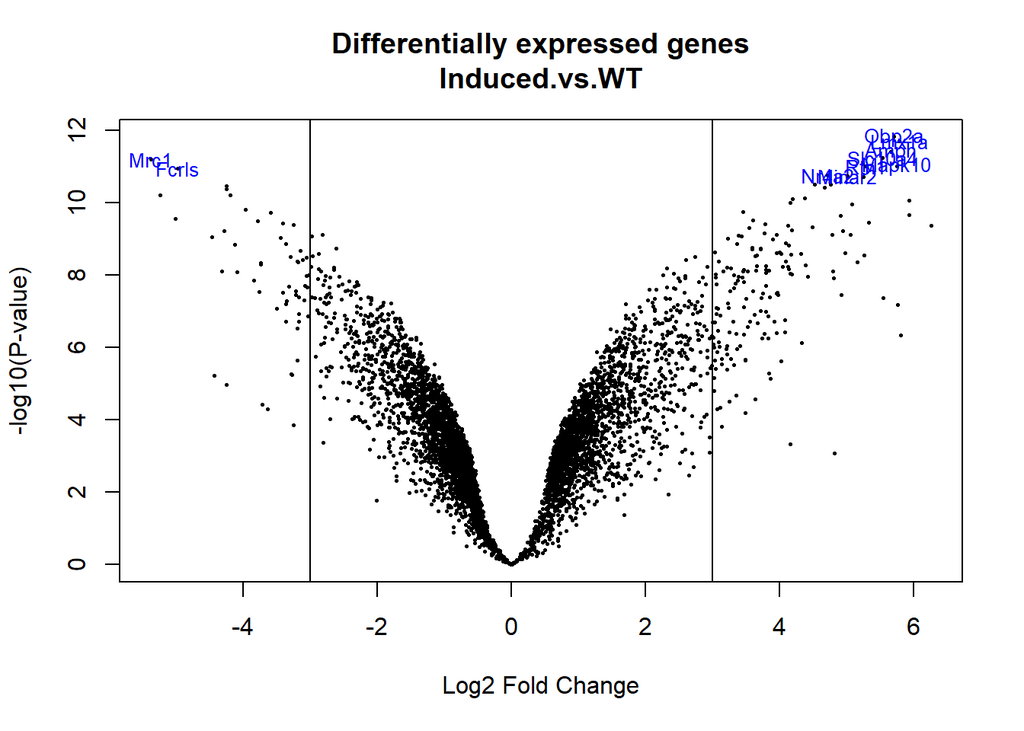

```r
genenames <- AnnotationDbi::select(mogene10sttranscriptcluster.db, rownames(fit.main1),
    c("SYMBOL"))$SYMBOL
volcanoplot(fit.main1, highlight = 10, names = genenames, main = paste("Differentially expressed genes",
    colnames(cont.matrix1), sep = "\n"))
abline(v = c(-3, 3))
```

```r
pdf(file.path(resultsDir, "Volcanos.pdf"))
volcanoplot(fit.main1, highlight = 10, names = genenames, main = paste("Differentially expressed genes",
    colnames(cont.matrix1), sep = "\n"))
abline(v = c(-3, 3))
dev.off()
```

## 6.3 Visualización de resultados (2): Heatmaps

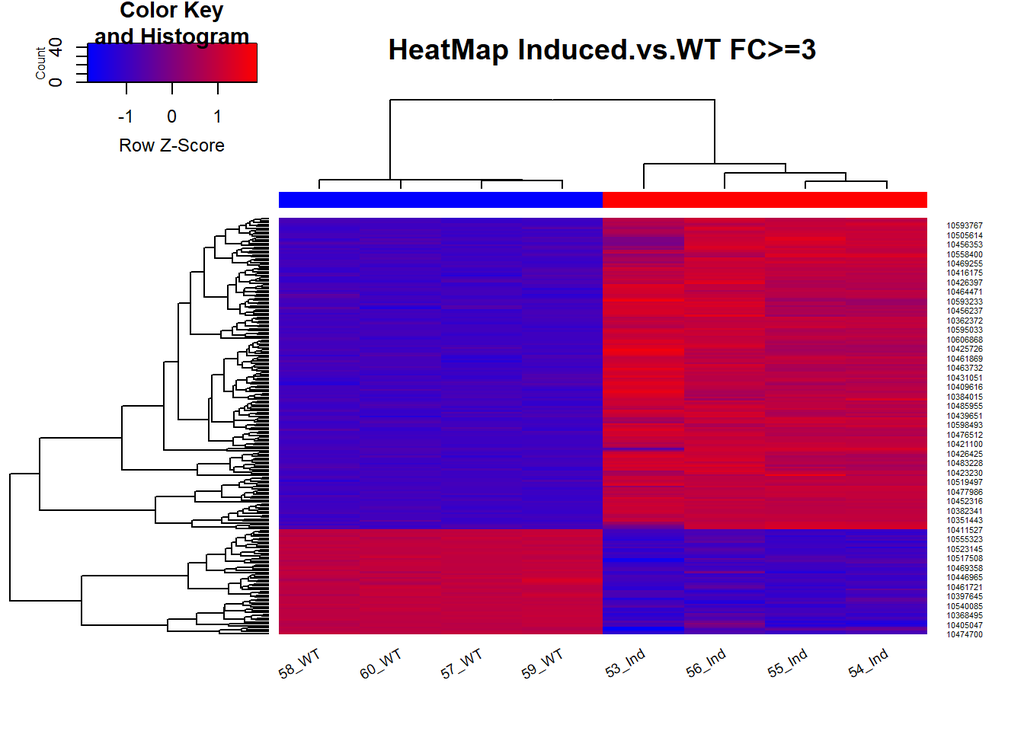

```r
selectedRows <- rownames(filteredData) %in% rownames(topTab)
selectedData <- filteredData[selectedRows, ]

# HEATMAP PLOT
my_palette <- colorRampPalette(c("blue", "red"))(n = 299)
library(gplots)
heatmap.2(selectedData, Rowv = TRUE, Colv = TRUE, main = "HeatMap Induced.vs.WT FC>=3",
    scale = "row", col = my_palette, sepcolor = "white", sepwidth = c(0.05, 0.05),
    cexRow = 0.5, cexCol = 0.9, key = TRUE, keysize = 1.5, density.info = "histogram",
    ColSideColors = c(rep("red", 4), rep("blue", 4)), tracecol = NULL, srtCol = 30)
```

```r
pdf(file.path(resultsDir, "Heatmap.pdf"))
heatmap.2(selectedData, Rowv = TRUE, Colv = TRUE, main = "HeatMap Induced.vs.WT FC>=3",
    scale = "row", col = my_palette, sepcolor = "white", sepwidth = c(0.05, 0.05),
    cexRow = 0.5, cexCol = 0.9, key = TRUE, keysize = 1.5, density.info = "histogram",
    ColSideColors = c(rep("red", 4), rep("blue", 4)), tracecol = NULL, srtCol = 30)
dev.off()
```

# 7 Análisis de significación biológica

A título ilustrativo realizaremos un análisis de enriquecimiento (“Over-Representation Analysis”) a partir de la lista de genes seleccionados como diferencialmente expresados.

Para el análisis necesitamos dos colecciones de genes

- La lista seleccionada
- El *universo de genes* es decir todos los genes que se han incluído en el análisis (hay quien pone todos los del chip o todos los del genoma).

La mayoría de programas necesitan que los identificadores de los genes sean en formato “ENTREZ” por lo que prepararemos ambas listas a la vez (aunque ya teníamos la de los genes seleccionados).

```r
library(mogene10sttranscriptcluster.db)
probesUniverse <- rownames(filteredData)
entrezUniverse <- AnnotationDbi::select(mogene10sttranscriptcluster.db, probesUniverse,
    "ENTREZID")$ENTREZID

topProbes <- rownames(selectedData)
entrezTop <- AnnotationDbi::select(mogene10sttranscriptcluster.db, topProbes, "ENTREZID")$ENTREZID

# Eliminamos posibles duplicados

topGenes <- entrezTop[!duplicated(entrezTop)]
entrezUniverse <- entrezUniverse[!duplicated(entrezUniverse)]
```

Se pueden utilizar muchos paquetes para realizar un análisis de enriquecimiento genético. Cada uno de ellos realiza un análisis ligeramente diferente, pero las ideas subyacentes son las mismas.

En este ejemplo usamos “GOstats”, que fue uno de los primeros paquetes disponibles en Bioconductor para realizar análisis de enriquecimiento.

```r
library(GOstats)

# This parameter has an 'ontology' argument. It may be 'BP', 'MF' or 'CC' Other
# arguments are taken by default. Check the help for more information.

GOparams = new("GOHyperGParams", geneIds = topGenes, universeGeneIds = entrezUniverse,
    annotation = "mogene10sttranscriptcluster.db", ontology = "BP", pvalueCutoff = 0.01)
```

```r
GOhyper = hyperGTest(GOparams)
```

```r
head(summary(GOhyper))
```

```
      GOBPID       Pvalue OddsRatio  ExpCount Count Size
1 GO:0023052 1.674590e-11  2.593310 79.074074   126 1830
2 GO:0007154 1.994143e-11  2.583724 79.246914   126 1834
3 GO:0007610 2.543149e-08  3.363218 12.790123    35  296
4 GO:0007218 3.396929e-08 15.450000  1.080247    10   25
5 GO:0007165 5.858866e-08  2.149668 70.086420   107 1622
6 GO:0007186 1.029648e-07  3.405959 11.061728    31  256
                                          Term
1                                    signaling
2                           cell communication
3                                     behavior
4               neuropeptide signaling pathway
5                          signal transduction
6 G protein-coupled receptor signaling pathway
```

```r
dim(summary(GOhyper))
```

```
[1] 250   7
```

```r
# Creamos un informe html con los resultados
GOfilename = file.path(resultsDir, "GOResults.html")
htmlReport(GOhyper, file = GOfilename, summary.args = list(htmlLinks = TRUE))
```